# LearnX Sales Forecasting

Anushree Tomar

28-03-2020

# Problem statement

LearnX is an online learning platform aimed at professionals and students. LearnX serves as a market place that allows instructors to build online courses on topics of their expertise which is later published after due diligence by the LearnX team. The platform covers a wide variety of topics including Development, Business, Finance & Accounting & Software Marketing and so on.

Effective forecasting for course sales gives essential insight into upcoming cash flow meaning business can more accurately plan the budget to pay instructors and other operational costs and invest in the expansion of the business.

Sales data for more than 2 years from 600 courses of LearnX’s top domains is available along with information on:-

• Competition in the market for each course

• Course Type (Course/Program/Degree)

• Holiday Information for each day

• User Traffic on Course Page for each day

Your task is to predict the course sales for each course in the test set for the next 60 days.

# Data Dictionary

The *Train data* (Historical Sales Data) has following attributes:-

| Variable | Definition |
| --- | --- |
| ID | Unique Identifier for a row |
| Day_No | Day Number |
| Course_ID | Unique ID for a course |
| Course_Domain | Course Domain (Development, Finance etc.) |
| Course_Type | Course/Program/Degree |
| Short_Promotio | Whether Short Term Promotion is Live |
| Public_Holiday | Regional/Public Holiday |
| Long_Promotion | Whether Long Term Promotion is Live for the course |
| User_Traffic | Number of customers landing on the course page |
| Competition_Metric | A metric defining the strength of competition |
| Sales (Target) | Total Course Sales |

The *Test data* (Next 60 Days)

This file contains the store and day number for which the participant needs to submit predictions/forecasts

| Variable | Definition |
| --- | --- |
| ID | Unique Identifier for a row |
| Day_No | Day Number |
| Course_ID | Unique ID for a course |
| Course_Domain | Course Domain (Development, Finance etc.) |
| Course_Type | Course/Program/Degree |
| Short_Promotion | Whether Short Term Promotion is Live |
| Public_Holiday | Regional/Public Holiday |
| Long_Promotion | Whether Long Term Promotion is Live for the course |
| Competition_Metric | A metric defining the strength of competition |

*Sample Submission*

This file contains the exact submission format for the forecasts. Please submit csv file only.

| Variable | Definition |
| --- | --- |
| ID | Unique Identifier for a row |
| Sales (Target) | Total Course Sales predicted from the test set |

# Evaluation Metric

The evaluation metric for this competition is 1000*RMSLE where RMSLE is Root of Mean Squared Logarithmic Error across all entries in the test set.

# Data Exploration

Now let’s explore the train data:-

# Train data

Top and Bottom of the data

| ID | Day_No | Course_ID | Course_Domain | Course_Type | Short_Promotion | Public_Holiday | Long_Promotion | User_Traffic | Competition_Metric | Sales |
| --- | --- | --- | --- | --- | --- | --- | --- | --- | --- | --- |
| 1 | 1 | 1 | Development | Course | 0 | 1 | 1 | 11004 | 0.007 | 81 |
| 2 | 2 | 1 | Development | Course | 0 | 0 | 1 | 13650 | 0.007 | 79 |
| 3 | 3 | 1 | Development | Course | 0 | 0 | 1 | 11655 | 0.007 | 75 |
| 4 | 4 | 1 | Development | Course | 0 | 0 | 1 | 12054 | 0.007 | 80 |
| 5 | 5 | 1 | Development | Course | 0 | 0 | 1 | 6804 | 0.007 | 41 |
| 6 | 6 | 1 | Development | Course | 0 | 0 | 1 | 10395 | 0.007 | 62 |

| ID | Day_No | Course_ID | Course_Domain | Course_Type | Short_Promotion | Public_Holiday | Long_Promotion | User_Traffic | Competition_Metric | Sales |
| --- | --- | --- | --- | --- | --- | --- | --- | --- | --- | --- |
| 548022 | 877 | 600 | Software Marketing | Program | 0 | 0 | 1 | 9072 | 0.07 | 111 |
| 548023 | 878 | 600 | Software Marketing | Program | 0 | 0 | 1 | 8904 | 0.07 | 114 |
| 548024 | 879 | 600 | Software Marketing | Program | 0 | 0 | 1 | 10542 | 0.07 | 145 |
| 548025 | 880 | 600 | Software Marketing | Program | 0 | 0 | 1 | 13671 | 0.07 | 167 |
| 548026 | 881 | 600 | Software Marketing | Program | 0 | 0 | 1 | 8904 | 0.07 | 107 |
| 548027 | 882 | 600 | Software Marketing | Program | 1 | 0 | 1 | 11445 | 0.07 | 152 |

Change the data type of attributes.

# Basic stats of the train data

```
##        ID             Day_No         Course_ID
##  Min.   :     1   2      :   600   1      :   882
##  1st Qu.:136963   3      :   600   2      :   882
##  Median :273984   4      :   600   3      :   882
##  Mean   :274007   5      :   600   4      :   882
##  3rd Qu.:411066   6      :   600   5      :   882
##  Max.   :548027   7      :   600   6      :   882
##                   (Other):508487   (Other):506795
##               Course_Domain     Course_Type     Short_Promotion Public_Holiday
##  Business            :  4410   Course :262747   0:317369        0:495885
##  Development         :264295   Degree :  1764   1:194718        1: 16202
##  Finance & Accounting: 77210   Program:247576
##  Software Marketing  :166172
##
##
##
##  Long_Promotion  User_Traffic    Competition_Metric     Sales
##  0:261693       Min.   :   168   Min.   :0.0000     Min.   :  0.0
##  1:250394       1st Qu.: 10584   1st Qu.:0.0100     1st Qu.: 84.0
##                 Median : 13776   Median :0.0350     Median :111.0
##                 Mean   : 15375   Mean   :0.0733     Mean   :120.8
##                 3rd Qu.: 18123   3rd Qu.:0.0940     3rd Qu.:146.0
##                 Max.   :100002   Max.   :0.7680     Max.   :682.0
##                                  NA's   :1764
```

# courses with Zero Sales

| ID | Day_No | Course_ID | Course_Domain | Course_Type | Short_Promotion | Public_Holiday | Long_Promotion | User_Traffic | Competition_Metric | Sales |
| --- | --- | --- | --- | --- | --- | --- | --- | --- | --- | --- |
| 119717 | 363 | 132 | Development | Course | 0 | 0 | 0 | 1050 | 0.021 | 0 |
| 120081 | 727 | 132 | Development | Course | 0 | 0 | 0 | 1050 | 0.021 | 0 |
| 120085 | 731 | 132 | Development | Course | 0 | 1 | 0 | 1029 | 0.021 | 0 |
| 145151 | 731 | 159 | Development | Program | 0 | 1 | 1 | 756 | 0.004 | 0 |
| 243951 | 371 | 267 | Development | Course | 1 | 1 | 0 | 714 | 0.449 | 0 |
| 244316 | 736 | 267 | Development | Course | 1 | 1 | 0 | 630 | 0.449 | 0 |
| 316334 | 360 | 346 | Development | Course | 0 | 1 | 1 | 672 | 0.004 | 0 |
| 316337 | 363 | 346 | Development | Course | 0 | 0 | 1 | 588 | 0.004 | 0 |
| 316340 | 366 | 346 | Development | Course | 0 | 1 | 1 | 588 | 0.004 | 0 |
| 341179 | 691 | 373 | Development | Course | 0 | 0 | 0 | 168 | 0.269 | 0 |

[output cut: 4 more lines]

There are some courses with Development Domain having zero sales on different Day No.

# Basic stats of the test data

```
##        ID             Day_No        Course_ID                  Course_Domain
##  Min.   :   883   883    :  600   1      :   60   Business            :  300
##  1st Qu.:137730   884    :  600   2      :   60   Development         :18480
##  Median :274762   885    :  600   3      :   60   Finance & Accounting: 5340
##  Mean   :274566   886    :  600   4      :   60   Software Marketing  :11880
##  3rd Qu.:410873   887    :  600   5      :   60
##  Max.   :548087   888    :  600   6      :   60
##                   (Other):32400   (Other):35640
##   Course_Type    Short_Promotion Public_Holiday Long_Promotion
##  Course :18600   0:21600         0:35605        0:17940
##  Degree :  120   1:14400         1:  395        1:18060
##  Program:17280
##
##
##
##
##  Competition_Metric
##  Min.   :0.00000
##  1st Qu.:0.01000
##  Median :0.03450
##  Mean   :0.07294
##  3rd Qu.:0.09400
##  Max.   :0.76800
##  NA's   :120
```

# Checking Missing data

| rows | columns | discrete_columns | continuous_columns | all_missing_columns | total_missing_values | complete_rows | total_observations | memory_usage |
| --- | --- | --- | --- | --- | --- | --- | --- | --- |
| 512087 | 11 | 7 | 4 | 0 | 1764 | 510323 | 5632957 | 26730600 |

# Total Sales by each Course

| Course_ID | Total_sales |
| --- | --- |
| 158 | 43836 |
| 124 | 44274 |
| 466 | 44869 |
| 153 | 45128 |
| 570 | 45685 |
| 444 | 46508 |
| 132 | 47225 |
| 327 | 47569 |
| 125 | 48458 |
| 375 | 49289 |

[output cut: 590 more lines]

# Visualization of the data

## Univariate and Bivariate Analysis

### Distribution of Course Domain

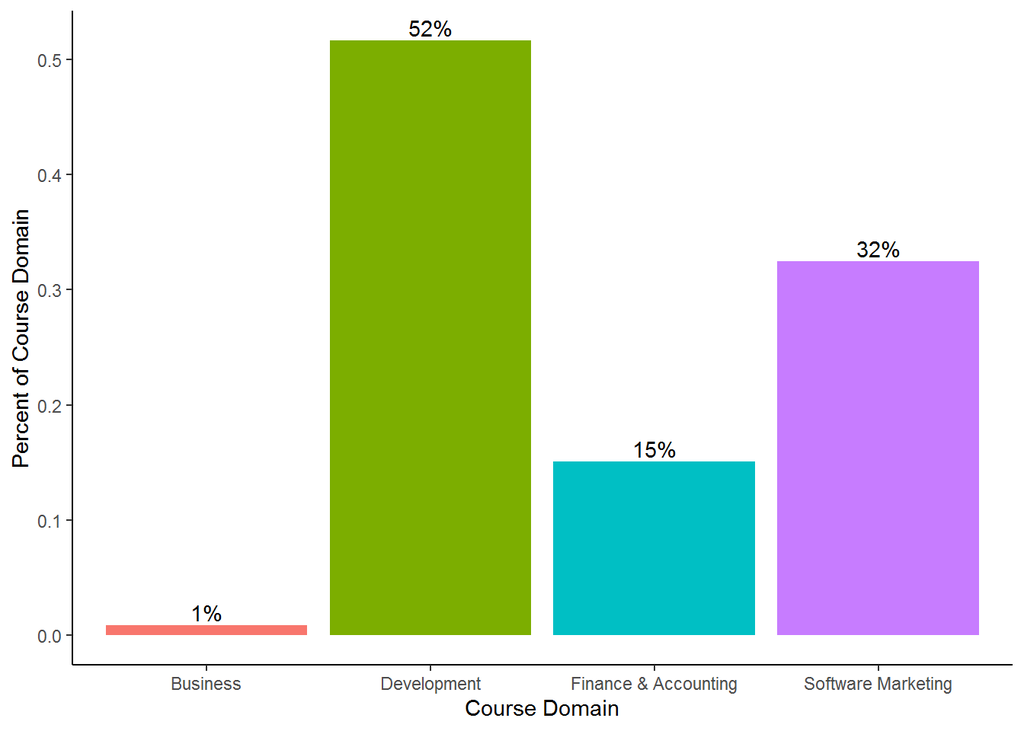

From the above graph we can see that out of 600 courses, *52%* of couses belongs to *Develpment* domain,*32%* of course belong to *Software Marketting* and *15%* of courses belongs to *Finance Accounting* while only *1%* of course belongs to *Business Domain*.

### Distribution of Course Type

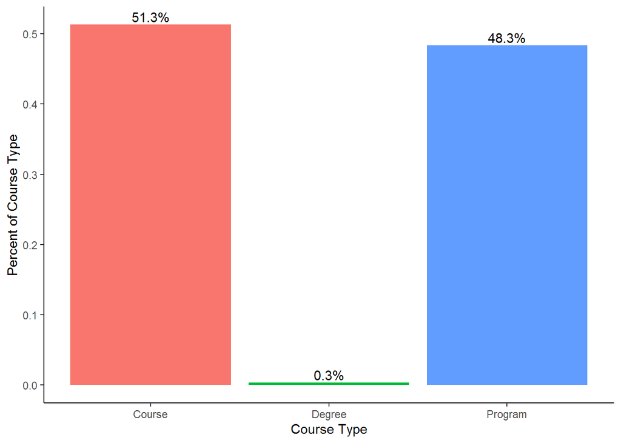

There are *51.3%* of Courses are *Course Type* and *48.3%* of courses *Progrme Type* while only *0.3%* of courses are of *Degree Type*.

### Comparative analysis of Course Domain and Course Type

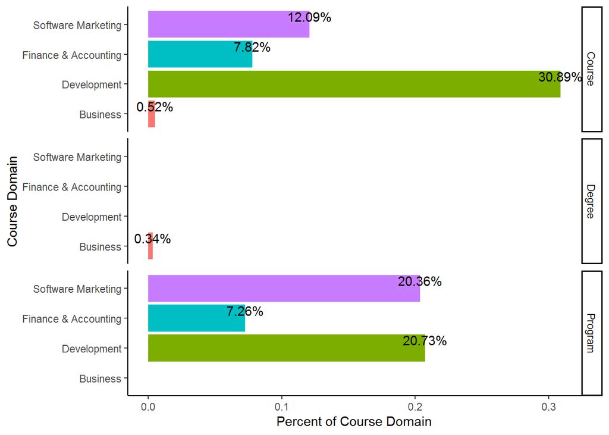

### Comparative analysis of Course Domain and User traffic

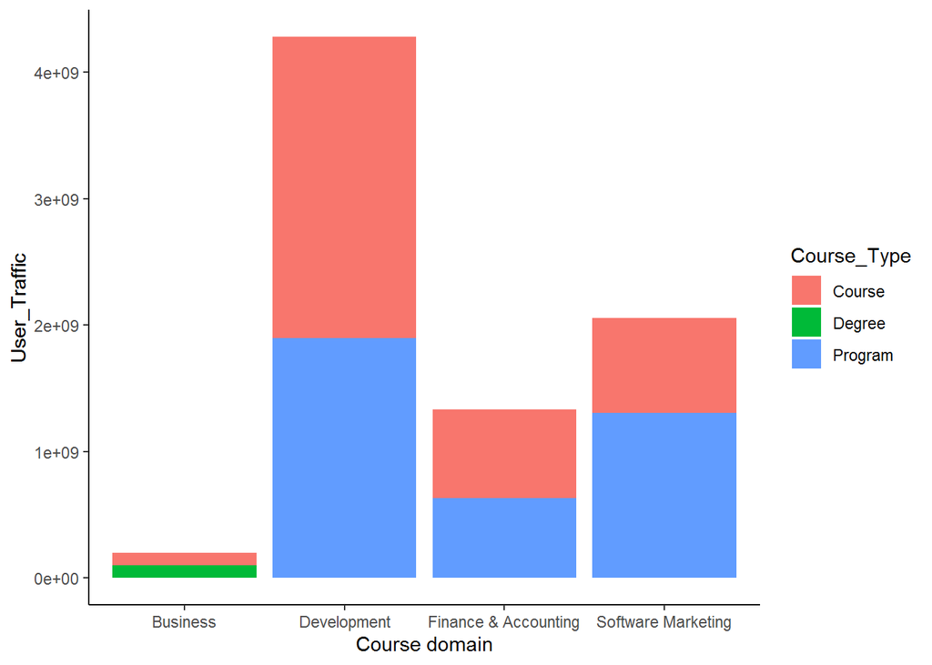

From the above graph we can conclude that there are more number of *user traffic* for *Development Domain* and for *Course Type* followed by *Software Marketting* for *Program Type*.

### Comparative analysis of Course Domain and Competitive Metric

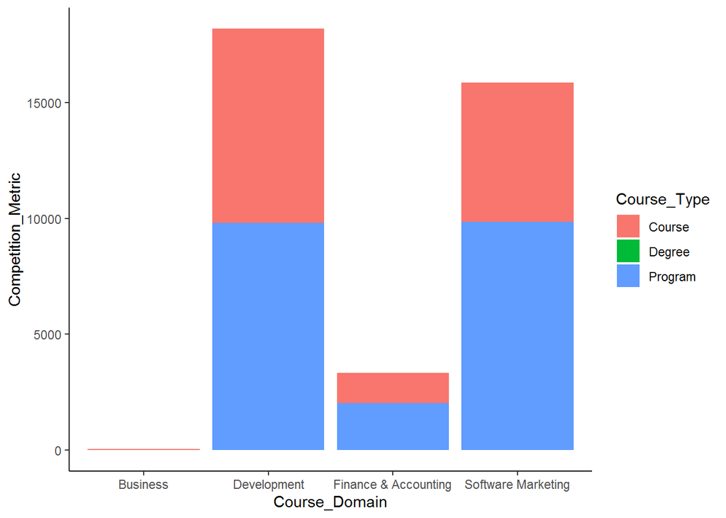

The strength of competition is more for *Development Domain* and of *Program Type*.

### Comparative analysis of Course Domain and Sales

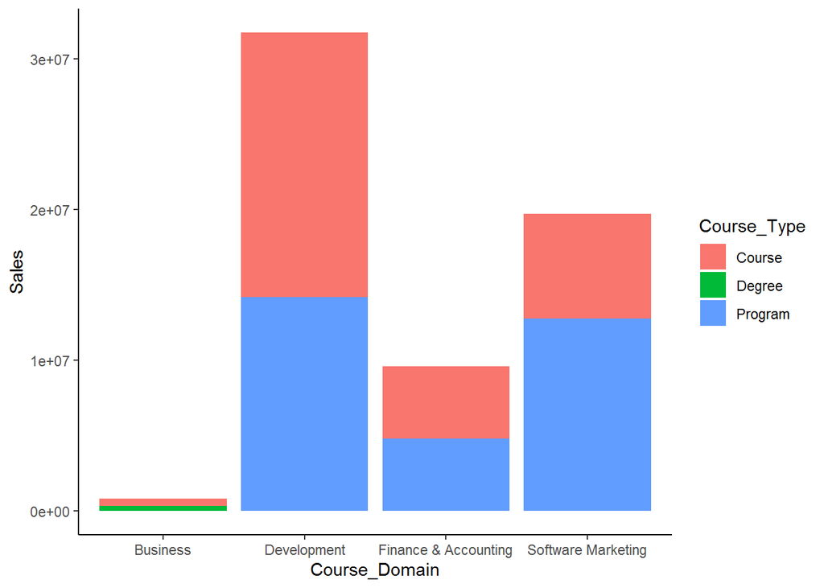

There are more sales for *Development Domain* courses and of *Course Type*, followed by *Software Marketting* for *Program Type*.

# Analyze the Effect of short Term promotion,Long term Promotion and Public Holidays on sales

## Short Promotion

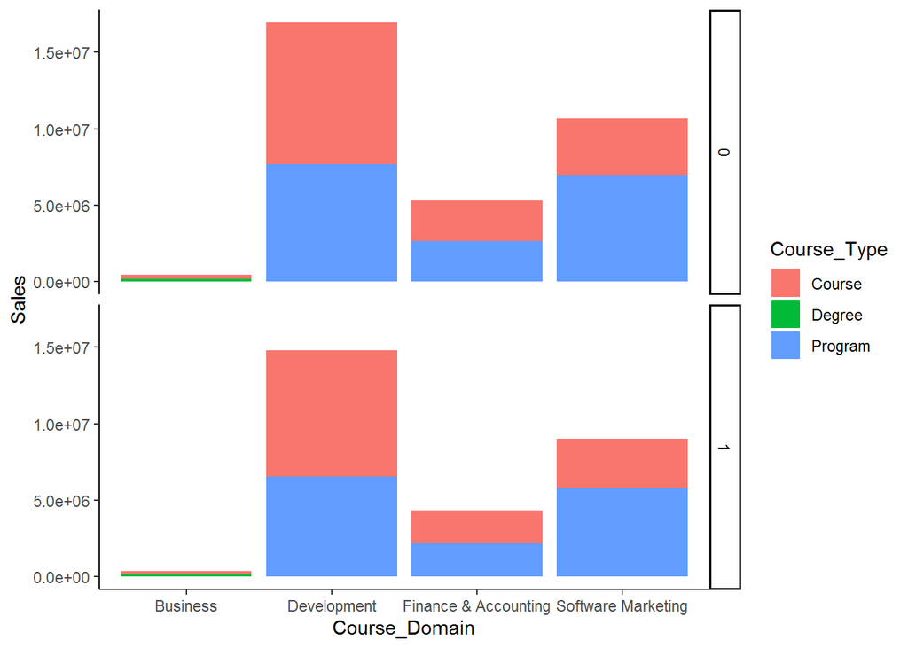

## Long Promotion

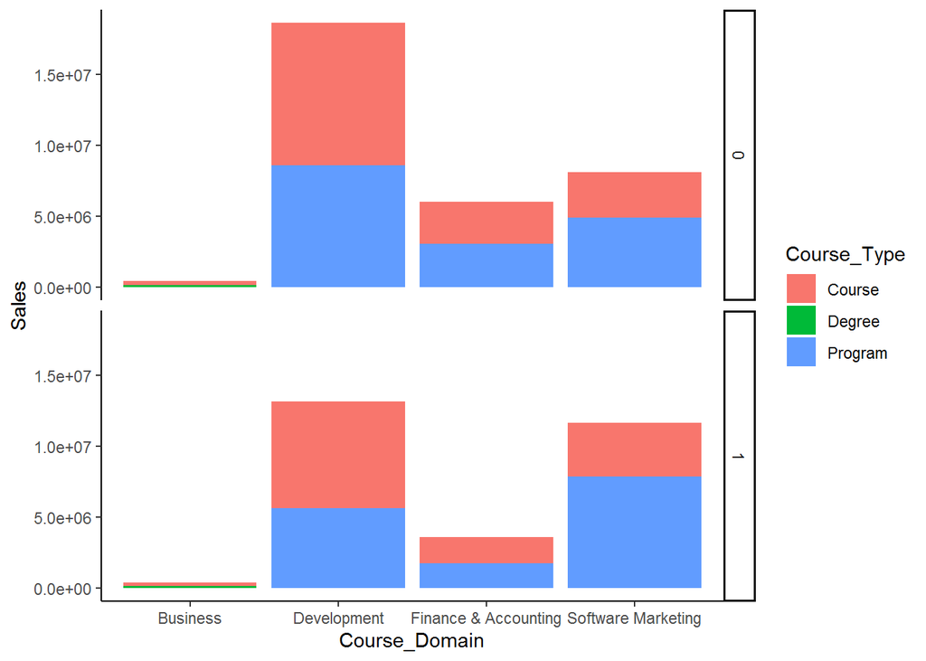

## Public Holiday

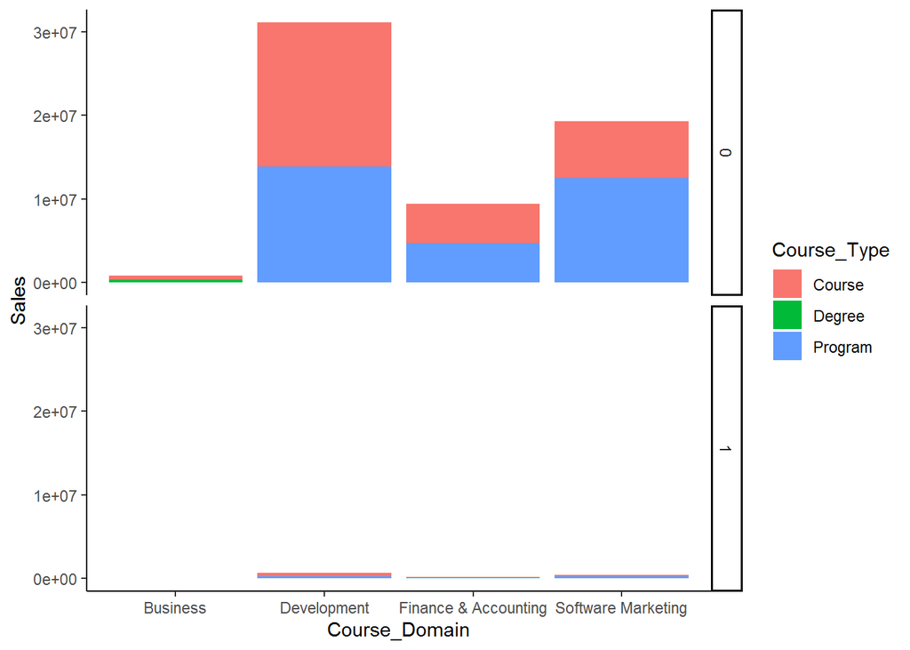

# Model Building

For model Building we need to pre-process the data and after that Data splitting into traindata and test data.

## Data Preprocessing

1- Imputation of missing values in the data.

2- Encoding of the Categorical features of the data.

```
## Classes 'data.table' and 'data.frame':   512087 obs. of  11 variables:
##  $ ID                : int  1 2 3 4 5 6 7 8 9 10 ...
##  $ Day_No            : num  1 2 3 4 5 6 7 8 9 10 ...
##  $ Course_ID         : num  1 1 1 1 1 1 1 1 1 1 ...
##  $ Course_Domain     : num  2 2 2 2 2 2 2 2 2 2 ...
##  $ Course_Type       : num  1 1 1 1 1 1 1 1 1 1 ...
##  $ Short_Promotion   : num  1 1 1 1 1 1 2 2 2 2 ...
##  $ Public_Holiday    : num  2 1 1 1 1 1 1 1 1 1 ...
##  $ Long_Promotion    : num  2 2 2 2 2 2 2 2 2 2 ...
##  $ User_Traffic      : int  11004 13650 11655 12054 6804 10395 16023 14385 16485 13377 ...
##  $ Competition_Metric: num  0.007 0.007 0.007 0.007 0.007 0.007 0.007 0.007 0.007 0.007 ...
##  $ Sales             : int  81 79 75 80 41 62 122 114 121 100 ...
##  - attr(*, ".internal.selfref")=<externalptr>
##  - attr(*, "index")= int
##   ..- attr(*, "__Sales")= int  111857 112221 112225 135671 227991 228356 295634 295637 295640 318859 ...
```

```
##        ID             Day_No        Course_ID     Course_Domain
##  Min.   :     1   Min.   :  1.0   Min.   :  1.0   Min.   :1.000
##  1st Qu.:136963   1st Qu.:214.0   1st Qu.:150.0   1st Qu.:2.000
##  Median :273984   Median :427.0   Median :300.0   Median :2.000
##  Mean   :274007   Mean   :434.9   Mean   :300.4   Mean   :2.791
##  3rd Qu.:411066   3rd Qu.:658.0   3rd Qu.:451.0   3rd Qu.:4.000
##  Max.   :548027   Max.   :882.0   Max.   :600.0   Max.   :4.000
##   Course_Type   Short_Promotion Public_Holiday  Long_Promotion
##  Min.   :1.00   Min.   :1.00    Min.   :1.000   Min.   :1.000
##  1st Qu.:1.00   1st Qu.:1.00    1st Qu.:1.000   1st Qu.:1.000
##  Median :1.00   Median :1.00    Median :1.000   Median :1.000
##  Mean   :1.97   Mean   :1.38    Mean   :1.032   Mean   :1.489
##  3rd Qu.:3.00   3rd Qu.:2.00    3rd Qu.:1.000   3rd Qu.:2.000
##  Max.   :3.00   Max.   :2.00    Max.   :2.000   Max.   :2.000
##   User_Traffic    Competition_Metric     Sales
##  Min.   :   168   Min.   :0.00000    Min.   :  0.0
##  1st Qu.: 10584   1st Qu.:0.01000    1st Qu.: 84.0
##  Median : 13776   Median :0.03500    Median :111.0
##  Mean   : 15375   Mean   :0.07335    Mean   :120.8
##  3rd Qu.: 18123   3rd Qu.:0.09400    3rd Qu.:146.0
##  Max.   :100002   Max.   :0.76800    Max.   :682.0
```

## Predictive Model and Evaluation

### Regression with Xgboost Model

# Prediction on test data

| ID | Sales |
| --- | --- |
| 883 | 134 |
| 884 | 129 |
| 885 | 122 |
| 886 | 122 |
| 887 | 69 |
| 888 | 69 |

# Important Features

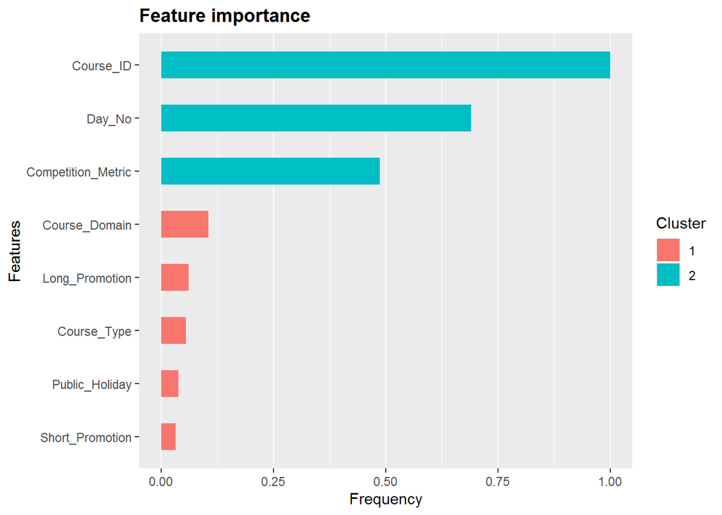

# Evaluation

For evaluation of model we will use 1000*RMSLE where RMSLE is Root of Mean Squared Logarithmic Error.

```
## [1] 188.3282
```

# Visualize Result

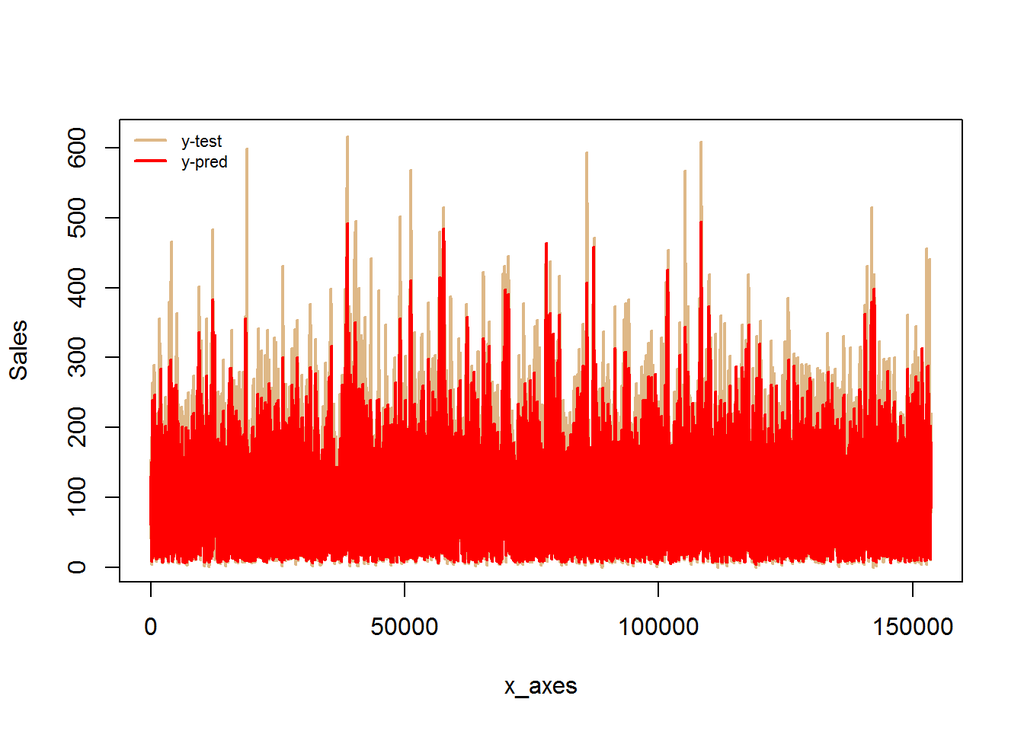

# Regression with CNN Model

# Extract the input dimension for the Keras model

```
## [1] 8 1
```

# Model Fitting

```
## Model: "sequential"
## ________________________________________________________________________________
## Layer (type)                        Output Shape                    Param #
## ================================================================================
## conv1d (Conv1D)                     (None, 7, 64)                   192
## ________________________________________________________________________________
## conv1d_1 (Conv1D)                   (None, 6, 64)                   8256
## ________________________________________________________________________________
## conv1d_2 (Conv1D)                   (None, 5, 64)                   8256
## ________________________________________________________________________________
## conv1d_3 (Conv1D)                   (None, 4, 64)                   8256
## ________________________________________________________________________________
## flatten (Flatten)                   (None, 256)                     0
## ________________________________________________________________________________
## dense (Dense)                       (None, 64)                      16448
## ________________________________________________________________________________
## dense_1 (Dense)                     (None, 64)                      4160
## ________________________________________________________________________________
## dense_2 (Dense)                     (None, 16)                      1040
## ________________________________________________________________________________
## dense_3 (Dense)                     (None, 8)                       136
## ________________________________________________________________________________
## dense_4 (Dense)                     (None, 1)                       9
## ================================================================================
## Total params: 46,753
## Trainable params: 46,753
## Non-trainable params: 0
## ________________________________________________________________________________
```

```
##     loss
## 895.0583
```

# Prediction on test data

| ID | Sales |
| --- | --- |
| 883 | 115 |
| 884 | 113 |
| 885 | 125 |
| 886 | 122 |
| 887 | 61 |
| 888 | 62 |

# Evaluation Metric

To evaluate our model we will use 1000*RMSLE where RMSLE is Root of Mean Squared Logarithmic Error.

```
## [1] 277.7862
```

# Visualize Result

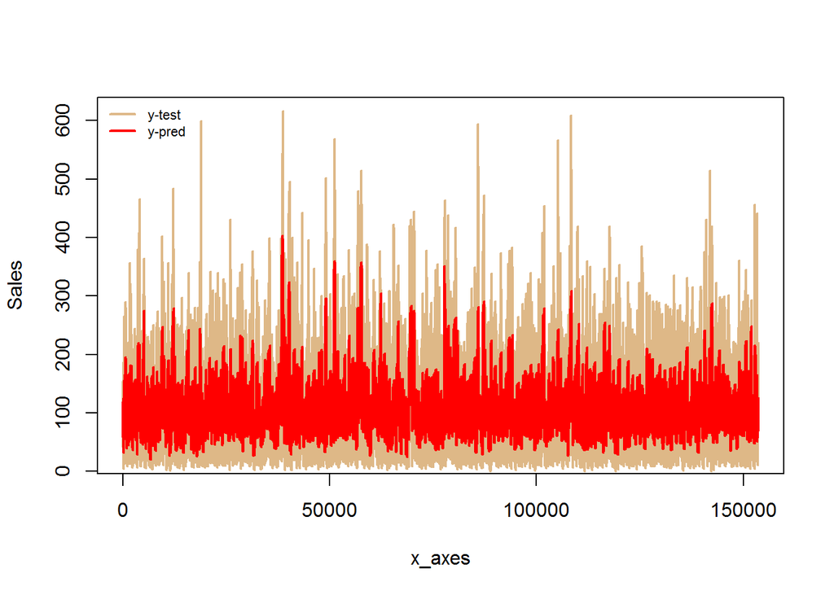

# Ensemble Model

Combine the result of all best models.

| ID | Sales |
| --- | --- |
| 883 | 124 |
| 884 | 121 |
| 885 | 120 |
| 886 | 119 |
| 887 | 66 |
| 888 | 66 |